# Import Data (Bonus)

```r
library(tidyverse)
```

This module will teach you an efficient way to import data stored in a flat file format. Flat file formats are one of the most common formats for saving data because flat files can be read by a large variety of data related software. Flat file formats include Comma Separated Values (csv’s), tab delimited files, fixed width files and more.

## readr

The **readr** R package contains simple, consistent functions for importing data saved as flat file documents. readr functions offer an alternative to base R functions that read in flat files. Compared to base R’s `read.table()` and its derivatives, readr functions have several advantages. readr functions:

- are ~10 times faster
- return user-friendly tibbles
- have more intuitive defaults. No rownames, no `stringsAsFactors = TRUE`.

readr supplies several related functions, each designed to read in a specific flat file format.

| Function | Reads |
| --- | --- |
| `read_csv()` | Comma separated values |
| `read_csv2()` | Semi-colon separate values |
| `read_delim()` | General delimited files |
| `read_fwf()` | Fixed width files |
| `read_log()` | Apache log files |
| `read_table()` | Space separated files |
| `read_tsv()` | Tab delimited values |

Here, we will focus on the `read_csv()` function, but the other functions work in a similar way. In most cases, you can use the syntax and arguments of `read_csv()` when using the other functions listed above.

readr is a core member of the tidyverse. It is loaded everytime you call `library(tidyverse)`.

## Sample data

A sample data set to import is saved alongside this notebook. The data set, saved as `nimbus.csv`, contains atmospheric ozone measurements of the southern hemisphere collected by NASA’s NIMBUS-7 satellite in October 1985. The data set is of historical interest because it displays evidence of the hole in the ozone layer collected shortly after the hole was first reported.

## Importing Data

To import `nimbus.csv`, use the readr functions that reads `.csv` files, `read_csv()`. Set the first argument of `read_csv()` to a characterstring: the filepath from your *working directory* to the `nimbus.csv` file.

So, if `nimbus.csv` is saved in your working directory, you can read it in with the command.

```r
nimbus <- read_csv("nimbus.csv")
```

Note: you can determine the location of your working directory by running `getwd()`. You can change the location of your working directory by going to **Session > Set Working Directory** in the RStudio IDE menu bar.

Notice that the code above saves the output to an object named nimbus. You must save the output of `read_csv()` to an object if you wish to use it later. If you do not save the output, `read_csv()` will merely print the contents of the data set at the command line.

## Your Turn 1

Find nimbus.csv on your server or computer. Then read it into an object. Then view the results.

```r
read.csv("nimbus.csv")
```

| date | longitude | latitude | ozone |
| --- | --- | --- | --- |
| 1985-10-01T00:00:00Z | -179.375 | -73.5 | 302 |
| 1985-10-01T00:00:00Z | -178.125 | -73.5 | 302 |
| 1985-10-01T00:00:00Z | -176.875 | -73.5 | 302 |
| 1985-10-01T00:00:00Z | -175.625 | -73.5 | 302 |
| 1985-10-01T00:00:00Z | -174.375 | -73.5 | 304 |
| 1985-10-01T00:00:00Z | -173.125 | -73.5 | 304 |
| 1985-10-01T00:00:00Z | -171.875 | -73.5 | 304 |
| 1985-10-01T00:00:00Z | -170.625 | -73.5 | 304 |
| 1985-10-01T00:00:00Z | -164.375 | -73.5 | 287 |
| 1985-10-01T00:00:00Z | -163.125 | -73.5 | 287 |

[output cut: 990 more lines]

## Tibbles

`read_csv()` reads the data into a **tibble**, which is a special class of data frame. Since a tibble is a sub-class of data frame, R will in most cases treat tibbles in exactly the same way that R treats data frames.

There is however, one notable exception. When R prints a data frame in the console window, R attempts to display the entire contents of the data frame. This has a negative effect: unless the data frame is very small you are left viewing the end of the data frame (or if the data frame is very large, the middle of the data frame since R stops displaying new rows after a maximum number is reached).

R will display tibbles in a much more sensible way. If the **tibble** package is loaded, R will display the first ten rows of the tibble and as many columns as will fit in your console window. This display ensures that the name of each column is visible in the display.

(Note that R Notebooks automatically display both tibbles and data frames as interactive tables, which hides this difference).

tibble is a core member of the tidyverse. It is loaded everytime you call `library(tidyverse)`. The tibble package includes the functions `tibble()` and `tribble()` for makign tibbles from scratch, as well as `as_tibble()` and `as.data.frame()` for converting back and forth between tibbles and data frames.

In almost every case, you can ignore whether or not you are working with tibbles or data frames.

## Parsing NA’s

```r
nimbus <- read_csv("nimbus.csv", na = ".")
```

You can set `na` to a single character string or a vector of character strings. `read_csv()` will transform every value listed in the `na` argument to an `NA` when it reads in the data.

## Parsing data types

If you run the code above and examine the results, you may now notice a new concern about the `ozone` column. The column has been parsed as character strings instead of numbers.

```r
nimbus <- read_csv("nimbus.csv", na = ".",
                   col_types = list(ozone = col_double()))
```

To complete the code, set `ozone` equal to one of the functions below, each function instructs `read_csv()` to parse `ozone` as a specific type of data.

| Type function | Data Type |
| --- | --- |
| `col_character()` | character |
| `col_date()` | Date |
| `col_datetime()` | POSIXct (date-time) |
| `col_double()` | double (numeric) |
| `col_factor()` | factor |
| `col_guess()` | let readr geuss (default) |
| `col_integer()` | integer |
| `col_logical()` | logical |
| `col_number()` | numbers mixed with non-number characters |
| `col_numeric()` | double or integer |
| `col_skip()` | do not read this column |
| `col_time()` | time |

In our case, we would use the `col_double()` function to ensure that `ozone` is read as a double (that is numeric) column.

## The hole in the ozone layer

Now that we have our data, we can use it to plot a picture of the hole in the ozone layer. Note that the “hole” in the ozone layer is the dark regions around the south pole. The actual “jhole” in the data is a smaller area centered on the south pole, where the satellite did not take measurements.

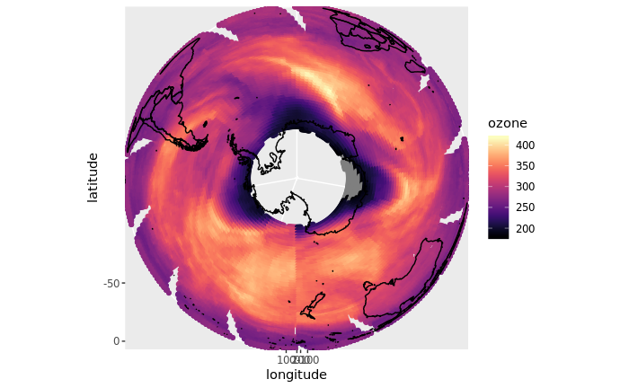

## Writing data

readr also contains functiomns for saving data. These functions parallel the read functions and each save a data frame or tibble in a specific file format.

| Function | Writes |
| --- | --- |
| `write_csv()` | Comma separated values |
| `write_excel_csv()` | CSV that you plan to open in Excel |
| `write_delim()` | General delimited files |
| `write_file()` | A single string, written as is |
| `write_lines()` | A vector of strings, one string per line |
| `write_tsv()` | Tab delimited values |

To use a write function, first give it the name of the data frame to save, then give it a filepath from your wqorking directory to the location where you would like to save the file. This filepath should end in the name of the new file. So we can save the clean `nimbus` data set as a csv in our working directory with

```r
write_csv(nimbus, path = "nimbus-clean.csv")
```

# Take Aways

The readr package provides efficient functions for reading and saving common flat file data formats.

Consider these packages for other types of data:

| Package | Reads |
| --- | --- |
| haven | SPSS, Stata, and SAS files |
| readxl | excel files (.xls, .xlsx) |
| jsonlite | json |
| xml2 | xml |
| httr | web API’s |
| rvest | web pages (web scraping) |
| DBI | databases |
| sparklyr | data loaded into spark |